# Citi Bike Jersey City

From Raw Trip Data to Spatial & Business Intelligence

Data Analytics Project

## 1. Citi Bike Jersey City

### From millions of ride events to actionable mobility insights

**Main question:**  
How can Citi Bike trip data be transformed into useful insights about **when, where, and under what conditions people ride?**

- Citi Bike trip data
- Weather enrichment
- Temporal and station analysis
- Neighborhood-level spatial analysis
- PostgreSQL + PostGIS
- Tableau dashboard

## 2. The Analytics Story

A Citi Bike trip tells us when and where a ride happened, the bike type, and whether the rider was a member or casual user.

But raw transactions do not directly explain:

- How demand changes through the year
- Which stations dominate the network
- How weather relates to ridership
- Which neighborhoods have the highest activity

### Goal: transform individual rides into meaningful mobility patterns.

## 3. Data Collection & Raw Structure

Monthly Jersey City Citi Bike ZIP files were downloaded automatically from the Citi Bike S3 repository.

- Python automated downloading and extraction
- Monthly CSV files were concatenated
- Duplicate `ride_id` values were removed
- The process was extended to **January–June 2026**

The original dataset contains **13 variables**:

| Category | Variables |
| --- | --- |
| Ride | `ride_id`, `rideable_type` |
| Time | `started_at`, `ended_at` |
| Start | station name/ID, latitude, longitude |
| End | station name/ID, latitude, longitude |
| Rider | `member_casual` |

## 4. Data Quality & Feature Engineering

Missing values were limited and concentrated mainly in destination information.

| Field | Missing | Share |
| --- | --- | --- |
| `end_station_id` | 4,265 | 0.448% |
| `end_lat / end_lng` | 3,425 | 0.360% |
| `end_station_name` | 3,128 | 0.329% |
| `start_station_name` | 3 | ~0.0003% |

After duration-related processing:

### **~951,743 working records**

New analytical features:

- Ride duration
- Date and month
- Day of week
- Hour
- Season

## 5. Weather Enrichment

Historical weather data for Jersey City was collected from **Open-Meteo** around coordinates **40.7178, -74.0431**.

Weather variables:

- Maximum, minimum, and average temperature
- Precipitation
- Rain
- Snowfall
- Maximum wind speed

Daily ride counts were merged with weather observations using **date**.

### Result: **0 missing values across merged weather variables**

## 6. Temporal Analysis: Monthly Demand

The analysis shows strong changes in demand throughout the year.

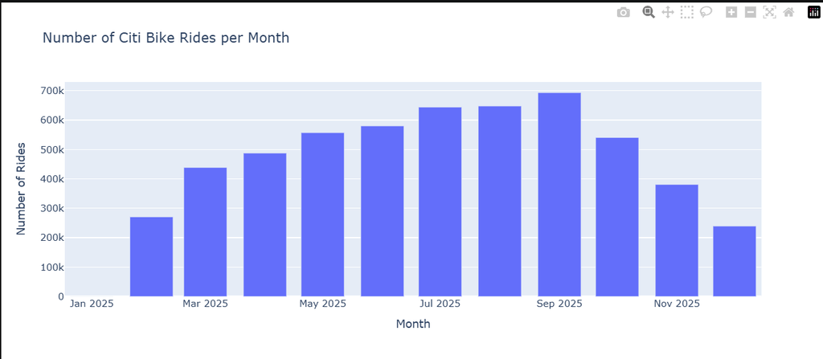

### September had the highest activity in the enriched monthly analysis.

## 7. Seasonality & Weather

### How does weather relate to Citi Bike demand?

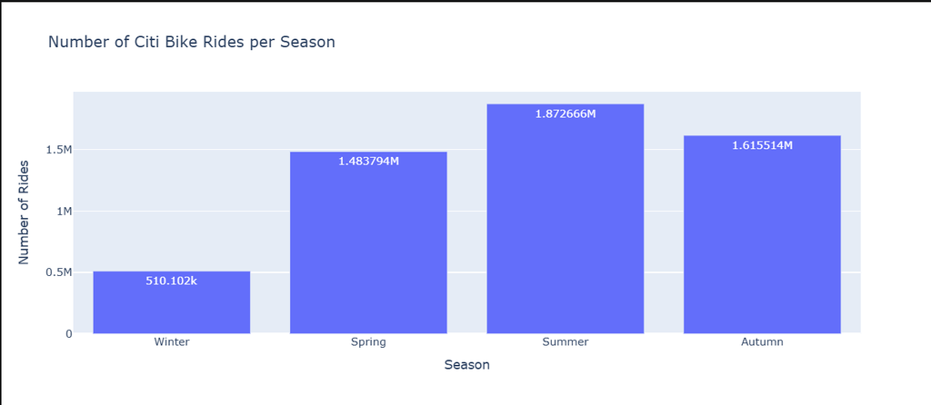

- Summer showed the highest activity
- Winter showed the lowest activity
- Temperature provides useful context for changes in daily ridership
- The relationship shows **association, not causality**

## 8. Station Analysis

### Top Starting Stations

| Station | Departures |
| --- | --- |
| **Grove St PATH** | **244,456** |
| Hoboken Terminal | 142,558 |
| Hamilton Park | 122,260 |
| River St & Newark St | 121,027 |
| Newport PATH | 113,275 |
| Exchange Pl | 110,247 |

### Top Ending Stations

| Station | Arrivals |
| --- | --- |
| **Grove St PATH** | **259,946** |
| Hoboken Terminal | 146,358 |
| River St & Newark St | 124,079 |
| Hamilton Park | 122,935 |
| Newport PATH | 114,186 |

## 9. Spatial Analysis

Station coordinates were converted into geographic points with **GeoPandas** using `EPSG:4326`.

The project identified:

- **480 stations** in the complete station dataset
- **78 stations** inside Jersey City neighborhood polygons
- **53 neighborhood polygons**

Interactive Folium maps were created for:

- Station locations
- Total activity
- Station count
- Average activity per station
- Departures and arrivals

## 10. Neighborhood Insights

| Neighborhood | Stations | Total Activity |
| --- | --- | --- |
| **Van Vorst Park** | 6 | **1,067,669** |
| Palus Hook | 6 | 658,549 |
| Newport | 2 | 434,986 |
| Journal Square | 3 | 356,885 |
| Hamilton Park | 2 | 349,111 |

### Van Vorst Park had the highest total neighborhood activity.

Average activity per station revealed another pattern:

- **Newport:** ~217,493
- **Van Vorst Park:** ~177,945
- **Hamilton Park:** ~174,556

## 11. PostgreSQL & PostGIS

The analytical data was moved into:

### **PostgreSQL 17 + PostGIS 3.4**

Main database objects:

- `jersey_city`
- `jersey_weather`
- `jersey_city_neighborhoods`
- `jc_2025_stations`

PostGIS validation:

- Neighborhoods → `ST_Polygon`
- Stations → `ST_Point`
- Coordinate system → **SRID 4326**

## 12. Preparing Data for Tableau

A dashboard-specific materialized view was created:

### `mv_tableau_citibike_dashboard`

It combines:

- Ride and rider information
- Date and time dimensions
- Ride duration and distance
- Weather
- Start and end neighborhoods
- Temperature groups
- Precipitation indicators

### Purpose: one optimized analytical source for Tableau.

## 13. Dashboard Data Quality & Performance

The materialized view contained:

### **948,659 rows**

Quality checks:

- **948,659 / 948,659** had weather information
- **948,659 / 948,659** had calculated distance
- **520,640** had start-neighborhood matches
- **516,527** had end-neighborhood matches

Indexes were added for:

- `ride_id`
- `ride_date`
- `ride_hour`
- `member_casual`

## 14. Final Tableau Dashboard

### Explore the Interactive Citi Bike Dashboard

[**Open Interactive Dashboard on Tableau Public**](https://public.tableau.com/app/profile/pertshuhi.papikyan/viz/CitiBikeJerseyCityanalysis/Dashboard1?publish=yes)

## 15. Key Findings

The analysis reveals a connected mobility story.

- Citi Bike demand shows strong **seasonality**
- Summer activity is substantially higher than winter
- **Grove St PATH** leads both origin and destination rankings
- Activity is concentrated in a relatively small number of neighborhoods
- **Van Vorst Park** leads total neighborhood activity
- **Newport** shows particularly high activity per station
- Weather provides context for daily demand variation
- Transport hubs repeatedly appear among the busiest locations

## 16. From Insight to Decision

The analysis can support operational decisions such as:

- Prioritizing high-demand stations
- Supporting bike rebalancing around transport hubs
- Anticipating seasonal demand changes
- Using weather as an additional planning signal
- Identifying neighborhoods with high activity per station
- Comparing arrivals and departures for imbalance
- Monitoring important origin-destination flows

## 17. Architecture & Limitations

### End-to-End Pipeline

```
Citi Bike Files
      ↓
Python Download & Cleaning
      ↓
Weather + GeoJSON Enrichment
      ↓
EDA + Spatial Analysis
      ↓
PostgreSQL + PostGIS
      ↓
Materialized View
      ↓
Tableau Dashboard
```

### Limitations

- Some destination information is missing
- Not all stations fall inside Jersey City neighborhood polygons
- Weather relationships show **association, not causality**
- Row counts differ across processing stages
- 2026 extension currently covers **January–June**

## 18. Conclusion

### From raw rides to a complete analytics workflow

The project combines:

- **Python + Pandas** — acquisition, cleaning, analytics
- **Open-Meteo** — weather enrichment
- **GeoPandas + Folium** — spatial analysis
- **PostgreSQL + PostGIS** — analytical storage
- **SQLAlchemy** — Python/database integration
- **Tableau** — interactive business intelligence

### Key takeaway

**The value came from connecting time, weather, geography, stations, and rider activity into one analytical story.**

### Thank You — Questions?

## 19. Contacts

- **Name:** Pertshuhi Papikyan
- **Email:** ppertshuhi@gmail.com
- **LinkedIn:** linkedin.com/in/pertshuhi-papikyan
- **GitHub:** github.com/Pertshuhipapikyan